# a3_task4_craig_kopulsky

Craig Kopulsky

11/1/2020

## Data Wrangling

```r
urchins_data <- read_csv(here("data", "urchins.csv")) %>%  # reading in urchins data
  clean_names() # converting variables to lowercase snake case
```

```r
# creating subset of urchins data focusing on Naples Reef
naples_reef_urchins <- urchins_data %>% # creating naples_reef_urchins from urchins_data dataset
  mutate(date = mdy(date)) %>% # creating a column for date in mdy form
  mutate(year = year(date), month = month(date)) %>% # creating separate columns for year and month
  filter(site == "NAPL" & common_name == "Purple Urchin" & year == 2010 & month == 1) # filtering dataset by site, common name, and date
```

## Exploratory Histograms

Exploring differences in size distributions among purple urchins for annual and control treatments

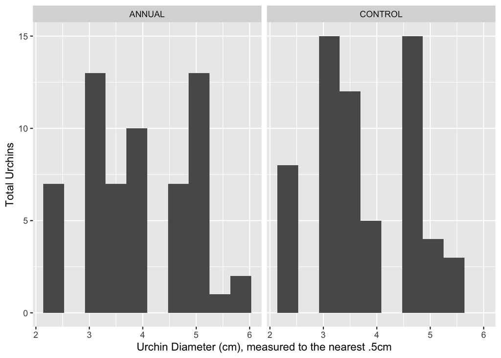

```r
ggplot(data = naples_reef_urchins, aes(size)) +
  geom_histogram(bins = 10) + # creating histogram with the urchins dataset showing distributions of sizes among Purple Urchins from Naples Reef, only including data from January 2010
  facet_wrap(~treatment) + # creating faceted histogram to show a comparison of size distributions between the two treatment conditions, Control and Annual
  labs(x = "Urchin Diameter (cm), measured to the nearest .5cm",
       y = "Total Urchins") # updating labels
```

Key Takeaways: Looking at the histograms, it appears that both samples have a roughly normal distribution with a slight skew to the left and relatively similar data spread.

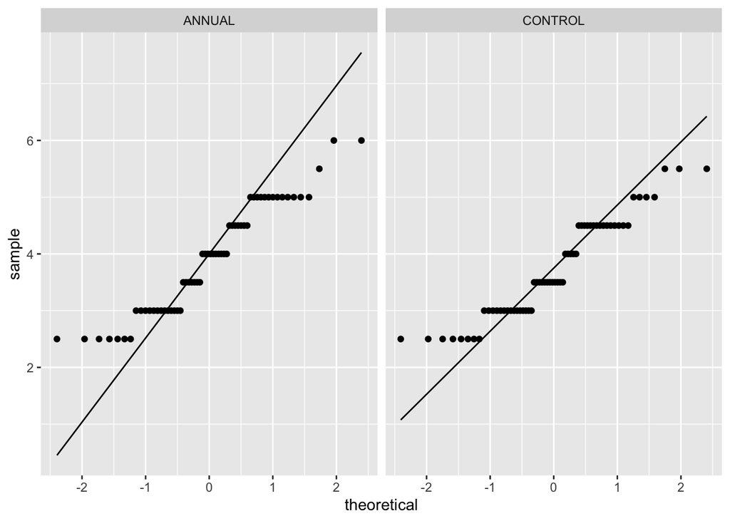

```r
ggplot(data = naples_reef_urchins, aes(sample = size)) +
  geom_qq() + # creating qq plot with the urchins dataset showing sample quantiles relative to theorhetical quantiles among Purple Urchins from Naples Reef, only including data from January 2010
  facet_wrap(~treatment) + #adding in theoretical line of normality
  stat_qq_line() # creating faceted qq plot to show a comparison of size distributions between the two treatment conditions, Control and Annual
```

```r
naples_reef_summary <- naples_reef_urchins %>% # creating summary table naples_reef_summary using naples_reef_urchins data set
  group_by(treatment) %>% # grouping by treatment
  summarize(mean = mean(size), median = median(size), sd = sd(size), n = n()) # including mean, median, sd, and sample size in summary table
  kbl(naples_reef_summary) %>%
  kable_styling(full_width = FALSE, "hover") # adding styling to the summary table
```

| treatment | mean | median | sd | n |
| --- | --- | --- | --- | --- |
| ANNUAL | 3.916667 | 4.0 | 0.9662380 | 60 |
| CONTROL | 3.725807 | 3.5 | 0.8668646 | 62 |

Comparing mean sizes between treatment groups with two-sample t-test

```r
annual_sample <- naples_reef_urchins %>% # creating vector annual_sample from naples_reef_urchins data set to use in t-test
  filter(treatment == "ANNUAL") %>% # filtering to include on annual treatment
  pull(size) # pulling the size data to create the vector

control_sample <- naples_reef_urchins %>% # creating vector control_sample from naples_reef_urchins data set to use in t-test
  filter(treatment == "CONTROL") %>% # filtering to include on annual treatment
  pull(size) # pulling the size data to create the vector

t.test(x = annual_sample, control_sample) # running t-test to compare annual and control sample means
```

```
##
##  Welch Two Sample t-test
##
## data:  annual_sample and control_sample
## t = 1.1472, df = 117.66, p-value = 0.2536
## alternative hypothesis: true difference in means is not equal to 0
## 95 percent confidence interval:
##  -0.1386165  0.5203369
## sample estimates:
## mean of x mean of y
##  3.916667  3.725806
```

The mean diameter for the annual treatment sample (3.9 cm) is about 5% larger than the mean diameter for the control treatment sample (3.7 cm). There is slightly more data spread in the annual treatment sample (.97 sd) than the control treatment sample (.87 sd).

The two sample t-test comparing the means of the two samples yields a p value of 0.2536 which indicates there is about a 25% chance that we would randomly draw two samples with means at least this far apart from each other if they were drawn from populations with the same means.

This p value is relatively large. Therefore, there is not enough evidence to reject the null hypothesis that the two samples come from populations with the same mean.